# Regression Analysis on Melbourne Housing Data

Chloé Winters

2025-10-09

# 1 Introduction

This assignment will look at housing data from Melbourne Australia and start the process of regression analysis. This will focus on both linear and logistic regression modeling based on the practical questions made in last weeks assignment.

# 2 Materials

## 2.1 Data Set

The data set being used in this analysis consists of 34,857 observations and 25 variables which are described below. This data set was created from publicly available results posted every week from Domain.com.au and then cleaned in the assignment last week. There is a mix of numerical and categorical data in this data set.

1. Suburb: (cat) suburb where the property is located
2. Rooms: (num) total number of rooms (including bedrooms and living areas)
3. Type: (cat) type of dwelling — house (h), unit/apartment (u), or townhouse (t)
4. Price: (num) sale price of the property in Australian dollars
5. Method: (cat) method of sale (e.g., sold, sold prior, passed in, withdrawn, etc.)
6. SellerG: (cat) real estate agency handling the sale
7. Date: (cat) sale date (in YYYY-MM-DD format)
8. Distance: (num) distance from the property to the Melbourne Central Business District (CBD) in kilometers
9. Postcode: (cat) postal code of the property location
10. Bedroom2: (num) number of bedrooms (from an alternate data source)
11. Bathroom: (num) number of bathrooms
12. Car: (num) number of car parking or garage spaces
13. Landsize: (num) land area of the property in square meters
14. CouncilArea: (cat) name of the local governing council for the property
15. Lattitude: (num) latitude coordinate of the property
16. Longtitude: (num) longitude coordinate of the property
17. Regionname: (cat) broader region classification of the suburb
18. Propertycount: (num) total number of properties within the suburb
19. SaleYear: (num) numeric year of sale extracted from the Date variable
20. SaleMonth: (cat) month of sale extracted from the Date variable (abbreviated form)
21. LogPrice: (num) log-transformed sale price used to reduce skewness in Price
22. CouncilAreaGrouped: (cat) grouped version of council areas to consolidate smaller categories
23. SuburbGrouped: (cat) grouped version of suburbs for improved model stability
24. SellerBinary: (num) binary variable for seller type (1 = large/major agency, 0 = small/local agency)
25. SoldBinary: (num) binary indicator of sale status (1 = sold by any method, 0 = not sold)

```r
url ="https://chloewinters79.github.io/STA551/Data/MelbourneHousing_Cleaned.csv"
house_cleaned = read.csv(url, header = TRUE)
```

# 3 Methodolgy & Analysis

## 3.1 Linear Model

To start the linear regression the assignment asks for a model to be created using practical variables. Since we are analyzing our practical question regarding price, which we did take the log of in the last assignment, we decided to make a model with the following variables, Rooms, Bathroom, Car, and Distance. From the summary output, all the variables have a p-value less than 0.05 and are statistically significant, and the same applies to the overall model.

```r
# Practical Model
lm_practical <- lm(LogPrice ~ Rooms + Bathroom + Car + Distance, data = house_cleaned)
summary(lm_practical)
```

```
Call:
lm(formula = LogPrice ~ Rooms + Bathroom + Car + Distance, data = house_cleaned)

Residuals:
     Min       1Q   Median       3Q      Max
-2.63079 -0.28053 -0.01365  0.26331  2.59910

Coefficients:
              Estimate Std. Error t value Pr(>|t|)
(Intercept) 13.0384490  0.0096475 1351.48   <2e-16 ***
Rooms        0.2695562  0.0038736   69.59   <2e-16 ***
Bathroom     0.1150725  0.0049363   23.31   <2e-16 ***
Car          0.0403212  0.0030472   13.23   <2e-16 ***
Distance    -0.0313234  0.0004206  -74.47   <2e-16 ***
---
Signif. codes:  0 '***' 0.001 '**' 0.01 '*' 0.05 '.' 0.1 ' ' 1

Residual standard error: 0.3913 on 20418 degrees of freedom
  (14434 observations deleted due to missingness)
Multiple R-squared:  0.4292,    Adjusted R-squared:  0.4291
F-statistic:  3838 on 4 and 20418 DF,  p-value: < 2.2e-16
```

For the second model the assignment calls for additional models to be added to the initial practical model to make a more expanded model. In addition to the variables in the first practical model this model includes, SellerBinary, Regionname, and Propertycount. Looking at the summary output for the model there is one variable that does not have a p-value less than 0.05, which is RegionnameNorthern Victoria. However all the other subsets of the Regionname variable have a p-value less than 0.05 indicating statistical significance. The model also has a p-value less than 0.05 and is statistically significant.

```r
# Extended Model
lm_extended <- lm(LogPrice ~ Rooms + Bathroom + Car + Distance + SellerBinary + Regionname + Propertycount, data = house_cleaned)
summary(lm_extended)
```

```
Call:
lm(formula = LogPrice ~ Rooms + Bathroom + Car + Distance + SellerBinary +
    Regionname + Propertycount, data = house_cleaned)

Residuals:
     Min       1Q   Median       3Q      Max
-2.68404 -0.22334 -0.00487  0.22040  2.37319

Coefficients:
                                       Estimate Std. Error  t value Pr(>|t|)
(Intercept)                           1.320e+01  1.297e-02 1017.876  < 2e-16
Rooms                                 2.884e-01  3.435e-03   83.946  < 2e-16
Bathroom                              6.476e-02  4.389e-03   14.755  < 2e-16
Car                                   4.590e-02  2.683e-03   17.107  < 2e-16
Distance                             -3.595e-02  4.952e-04  -72.583  < 2e-16
SellerBinary                          4.467e-02  5.026e-03    8.887  < 2e-16
RegionnameEastern Victoria            2.534e-01  3.151e-02    8.041 9.42e-16
RegionnameNorthern Metropolitan      -2.544e-01  8.850e-03  -28.750  < 2e-16
RegionnameNorthern Victoria           3.391e-02  3.141e-02    1.080     0.28
RegionnameSouth-Eastern Metropolitan  1.571e-01  1.365e-02   11.503  < 2e-16
RegionnameSouthern Metropolitan       1.011e-01  8.635e-03   11.708  < 2e-16
RegionnameWestern Metropolitan       -3.154e-01  8.811e-03  -35.792  < 2e-16
RegionnameWestern Victoria           -2.988e-01  3.918e-02   -7.627 2.51e-14
Propertycount                        -3.041e-06  5.766e-07   -5.274 1.35e-07

(Intercept)                          ***
Rooms                                ***
Bathroom                             ***
Car                                  ***
Distance                             ***
SellerBinary                         ***
RegionnameEastern Victoria           ***
RegionnameNorthern Metropolitan      ***
RegionnameNorthern Victoria
RegionnameSouth-Eastern Metropolitan ***
RegionnameSouthern Metropolitan      ***
RegionnameWestern Metropolitan       ***
RegionnameWestern Victoria           ***
Propertycount                        ***
---
Signif. codes:  0 '***' 0.001 '**' 0.01 '*' 0.05 '.' 0.1 ' ' 1

Residual standard error: 0.3435 on 20409 degrees of freedom
  (14434 observations deleted due to missingness)
Multiple R-squared:  0.5604,    Adjusted R-squared:  0.5601
F-statistic:  2001 on 13 and 20409 DF,  p-value: < 2.2e-16
```

Finally, the assignment asks for a variable selection method to identify the optimal final model. For this data set, stepwise direction will be used to determine the optimal model. The final model turns out to be a replica of the extended model, none of the variables were removed and no new variables were added.

```r
lm_final <- stepAIC(lm_extended, direction = "both", trace = FALSE)
summary(lm_final)
```

```
Call:
lm(formula = LogPrice ~ Rooms + Bathroom + Car + Distance + SellerBinary +
    Regionname + Propertycount, data = house_cleaned)

Residuals:
     Min       1Q   Median       3Q      Max
-2.68404 -0.22334 -0.00487  0.22040  2.37319

Coefficients:
                                       Estimate Std. Error  t value Pr(>|t|)
(Intercept)                           1.320e+01  1.297e-02 1017.876  < 2e-16
Rooms                                 2.884e-01  3.435e-03   83.946  < 2e-16
Bathroom                              6.476e-02  4.389e-03   14.755  < 2e-16
Car                                   4.590e-02  2.683e-03   17.107  < 2e-16
Distance                             -3.595e-02  4.952e-04  -72.583  < 2e-16
SellerBinary                          4.467e-02  5.026e-03    8.887  < 2e-16
RegionnameEastern Victoria            2.534e-01  3.151e-02    8.041 9.42e-16
RegionnameNorthern Metropolitan      -2.544e-01  8.850e-03  -28.750  < 2e-16
RegionnameNorthern Victoria           3.391e-02  3.141e-02    1.080     0.28
RegionnameSouth-Eastern Metropolitan  1.571e-01  1.365e-02   11.503  < 2e-16
RegionnameSouthern Metropolitan       1.011e-01  8.635e-03   11.708  < 2e-16
RegionnameWestern Metropolitan       -3.154e-01  8.811e-03  -35.792  < 2e-16
RegionnameWestern Victoria           -2.988e-01  3.918e-02   -7.627 2.51e-14
Propertycount                        -3.041e-06  5.766e-07   -5.274 1.35e-07

(Intercept)                          ***
Rooms                                ***
Bathroom                             ***
Car                                  ***
Distance                             ***
SellerBinary                         ***
RegionnameEastern Victoria           ***
RegionnameNorthern Metropolitan      ***
RegionnameNorthern Victoria
RegionnameSouth-Eastern Metropolitan ***
RegionnameSouthern Metropolitan      ***
RegionnameWestern Metropolitan       ***
RegionnameWestern Victoria           ***
Propertycount                        ***
---
Signif. codes:  0 '***' 0.001 '**' 0.01 '*' 0.05 '.' 0.1 ' ' 1

Residual standard error: 0.3435 on 20409 degrees of freedom
  (14434 observations deleted due to missingness)
Multiple R-squared:  0.5604,    Adjusted R-squared:  0.5601
F-statistic:  2001 on 13 and 20409 DF,  p-value: < 2.2e-16
```

```r
# View final model formula
formula(lm_final)
```

```
LogPrice ~ Rooms + Bathroom + Car + Distance + SellerBinary +
    Regionname + Propertycount
```

When looking at the model comparisons we are looking for the highest adjusted R squared value and the lowest AIC. In this case this it both the extended and stepwise model, which makes sense considering they are the same model. Which means that final/extended model is the better model compared to the practical model.

```r
model_comparison <- data.frame(
  Model = c("Practical", "Extended", "Final (Stepwise)"),
  Adj_R2 = c(summary(lm_practical)$adj.r.squared,
             summary(lm_extended)$adj.r.squared,
             summary(lm_final)$adj.r.squared),
  AIC = c(AIC(lm_practical),
          AIC(lm_extended),
          AIC(lm_final))
)
model_comparison
```

```
             Model    Adj_R2      AIC
1        Practical 0.4291003 19635.22
2         Extended 0.5600797 14321.57
3 Final (Stepwise) 0.5600797 14321.57
```

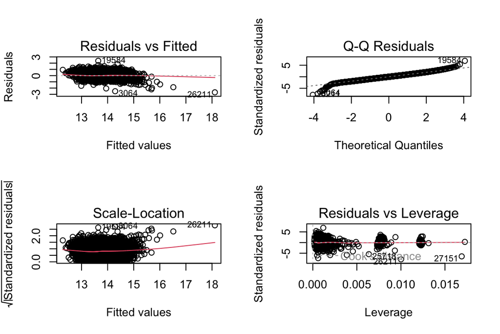

```r
par(mfrow = c(2, 2))
plot(lm_final)
```

```r
library(car)
vif(lm_final)
```

```
                  GVIF Df GVIF^(1/(2*Df))
Rooms         1.827852  1        1.351981
Bathroom      1.647039  1        1.283370
Car           1.231948  1        1.109931
Distance      2.002525  1        1.415106
SellerBinary  1.065685  1        1.032320
Regionname    2.180520  7        1.057263
Propertycount 1.120352  1        1.058467
```

```r
exp_coef <- exp(coef(lm_final)) - 1
round(exp_coef, 3)
```

```
                         (Intercept)                                Rooms
                          542593.924                                0.334
                            Bathroom                                  Car
                               0.067                                0.047
                            Distance                         SellerBinary
                              -0.035                                0.046
          RegionnameEastern Victoria      RegionnameNorthern Metropolitan
                               0.288                               -0.225
         RegionnameNorthern Victoria RegionnameSouth-Eastern Metropolitan
                               0.034                                0.170
     RegionnameSouthern Metropolitan       RegionnameWestern Metropolitan
                               0.106                               -0.270
          RegionnameWestern Victoria                        Propertycount
                              -0.258                                0.000
```